# **Finding the best area for beginners of Zelda: Breath of the Wild**

### **Introduce the problem**

Many players began playing their first game on the Nintendo Switch with Zelda: Breath of the Wild, as it is one of the highest grossing games in the franchise and in Nintendo history. The game itself is open-world, letting players chose which direction to go and how they would like to complete the story. One of the biggest issues people have is understanding how to survive in the game, especially those who don't play too many games and bought it due to its popularity. I am hoping to find a solution or a guide to beginners or regular players of the game. Using data based on the "Hyrule Compendium", I am looking for the most optimal spot in the map, which provides players with the best materials and creatures to survive the longest.

### **Introduce the data**

To achieve this goal, I will need to see all creatures and materials in the game, and all stats that are involved with it. This is provided through a dataset of the "Hyrule Compendium", from Zelda: Breath of The Wild. This includes file consisting of all creatures in the game, the regions they are found in, attainable hearts, and type.

First, I will start with importing the necessary dataset, and all necessary libraries to address this problem.

```python
!pip install pandas
```

```python
import pandas as pd
```

```python
materials_df = pd.read_csv("data/Hyrule Compendium_Breath _of_the_Wild Nulls - Material.csv")
```

Now let's make sure the data is properly working:

```python
materials_df.head()
```

|  | Reference Number | Name | Common Locations | Common Locations 2 | Cooking Effects | Hearts Recovered | Type |
| --- | --- | --- | --- | --- | --- | --- | --- |
| 0 | 162 | Apple | Hyrule Field | East Necluda | Heart Recovery | 0.5 | Fruit |
| 1 | 163 | Palm Fruit | East Necluda | Gerudo Desert | Heart Recovery | 1.0 | Fruit |
| 2 | 164 | Wildberry | Gerudo Highlands | Hebra Mountains | Heart Recovery | 0.5 | Fruit |
| 3 | 165 | Hearty Durian | West Necluda | Faron Grasslands | Extra Hearts | 3.0 | Fruit |
| 4 | 166 | Hydromelon | Gerudo Desert | Faron Grasslands | Heat Resistance | 0.5 | Fruit |

```python
materials_df.shape
```

```
(36, 7)
```

### **Pre-processing**

First, we will need to check if we have to deal with any nulls in this dataset.

```python
materials_df.isna().sum()
```

```
Reference Number      0
Name                  0
Common Locations      0
Common Locations 2    3
Cooking Effects       0
Hearts Recovered      0
Type                  0
dtype: int64
```

Looks like there are 3 nulls in the "Common Locations 2" column. Since it is a secondary area where these materials can be found, we can assume they can only be found in the original "Common Locations" column. We will fill these nulls with the same value entered in each respective "Common Locations" column.

```python
materials_df['Common Locations 2'] = materials_df['Common Locations 2'].fillna(
    materials_df['Common Locations']
)
```

Let's see if the nulls are removed now:

```python
materials_df.isna().sum()
```

```
Reference Number      0
Name                  0
Common Locations      0
Common Locations 2    0
Cooking Effects       0
Hearts Recovered      0
Type                  0
dtype: int64
```

The data looks good! Now we can go into understanding the data and finding the best area/materials for beginners of the game.

### **Data Understanding/Visualization**

When players begin the game, the first area they get to discover is Hyrule Field, so we can first look at what players can find in that area.

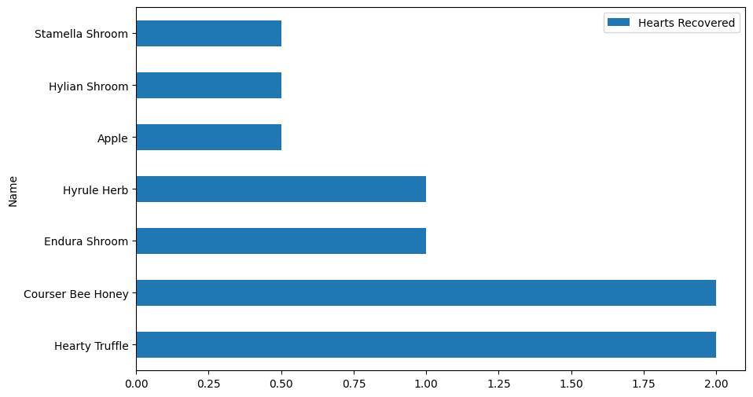

```python
# Create a variable for all materials in Hyrule Field
hyrule_field_materials = materials_df[
    (materials_df["Common Locations"] == "Hyrule Field") |
    (materials_df["Common Locations 2"] == "Hyrule Field")
]

# Sort by Hearts Recovered in descending order
hyrule_field_materials = hyrule_field_materials.sort_values(by="Hearts Recovered", ascending=False)

hyrule_field_materials.plot(
    kind="barh",
    x="Name",
    y="Hearts Recovered",
    figsize=(10, 6)
)
```

Now we can see that the materials with the most recoverable hearts are the Courser Bee Honey and the Hearty Truffle! Based on this, players should look for these materials when they are low on health.

There is a lot more for players to explore though, and they can use these materials to cook as well! Cooking materials will give more hearts if done right, so what materials are best to use?

To decide, we will see what gives extra hearts and heart recovery effects, this time including all the regions across the map.

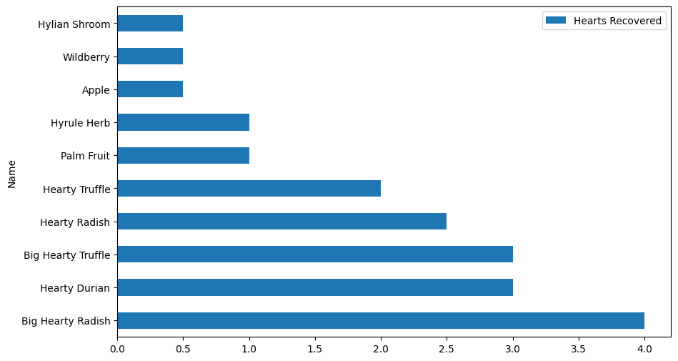

```python
# Filter materials with 'Extra Hearts' or 'Heart Recovery' cooking effects
heart_cooking_effects = materials_df[
    materials_df["Cooking Effects"].isin(["Extra Hearts", "Heart Recovery"])
]

# Sort by Hearts Recovered in descending order
filtered_materials = heart_cooking_effects.sort_values(by="Hearts Recovered", ascending=False)

filtered_materials.plot(
    kind="barh",
    x="Name",
    y="Hearts Recovered",
    figsize=(10, 6)
)
```

Now we can confirm the best material for players to look for, and to cook with. It is the Big Hearty Radish, with a recovery rate of 4 hearts. If players cannot find it, they can use any of the other materials to cook or eat for heart recovery.

### **Storytelling**

Based on the previous graphs, we can now confirm the best materials for players to look for, both in the beginning of the game and at any other point of the game until the end. Players could reference this graph to see what to look for if they are low on hearts, or want to prepare food to cook with in the game.

This helped me solve my initial question, and gave a guide towards new players that may not know how to survive the initial area of the game. This research ended up being successful, and I can even reference it myself if I play the game again.

### **Impact**

This project is targeted towards players of the game The Legend of Zelda: Breath of the Wild. These visualizations provide a further detailed version of materials found in the game and what to look for when playing the game. One way the visualizations could harm players is due to the lack of information regarding rarity of each item. Players may look for the best materials based on the visualizations, but there is chance that it hard to come across, and they can end up wasting time looking for more of those items. On the other hand, the second visualization can come to use due to the information it provides. The materials shown on that graph have the same effects, but they may have less effect than others. If users cannot find what they're looking for, they can make use of the materials they may already have. Overall, the provided information and dataframe are useful, but it could include some more details about the materials themselves.

### **References**

[Kaggle](https://www.kaggle.com/datasets/elisamork/zelda-breath-of-the-wild-hyrule-compendium)

[W3Schools](https://www.w3schools.com/python/pandas/pandas_plotting.asp)